# Chapter 2

```r
require(data.table)
require(ggplot2)
theme_set(
    theme_bw(base_size = 14, base_family = "Lato") +
    theme(panel.grid = element_blank(), panel.border = element_blank())
)
```

In this chapter we will be learning syntax for performing most common data manipulation tasks:

- pick variables based on their names
- pick rows based on their values
- aggregate data (counting) by groups

## 2.1 Import data

We’re going to use a new dataset here, to demonstrate how to deal with larger datasets. This is a subset of the of 311 service requests from [NYC Open Data](https://nycopendata.socrata.com/Social-Services/311-Service-Requests-from-2010-to-Present/erm2-nwe9).

```r
complaints <- fread("../data/311-service-requests.csv")
sprintf("Shape of the dataset: %d observations and %d variables", NROW(complaints), NCOL(complaints))
```

```
#> [1] "Shape of the dataset: 111069 observations and 52 variables"
```

## 2.2 What’s even in it? (the summary)

Let’s take a look at the dataset. By default, the `print` function for `data.table` object only show the first 5 rows and the last 5 rows. (For illustrative purpose, I already truncated the output)

```r
print(complaints) # long-scrolling
```

```
#>         Unique Key           Created Date            Closed Date Agency
#>      1:   26589651 10/31/2013 02:08:41 AM                          NYPD
#>      2:   26593698 10/31/2013 02:01:04 AM                          NYPD
#>      3:   26594139 10/31/2013 02:00:24 AM 10/31/2013 02:40:32 AM   NYPD
#>      4:   26595721 10/31/2013 01:56:23 AM 10/31/2013 02:21:48 AM   NYPD
#>      5:   26590930 10/31/2013 01:53:44 AM                         DOHMH
#>     ---
#> 111065:   26426013 10/04/2013 12:01:13 AM 10/07/2013 04:07:16 PM    DPR
#> 111066:   26428083 10/04/2013 12:01:05 AM 10/04/2013 02:13:50 AM   NYPD
#> 111067:   26428987 10/04/2013 12:00:45 AM 10/04/2013 01:25:01 AM   NYPD
#> 111068:   26426115 10/04/2013 12:00:28 AM 10/04/2013 04:17:32 AM   NYPD
#> 111069:   26428033 10/04/2013 12:00:10 AM 10/04/2013 01:20:52 AM   NYPD
#>                                     Agency Name          Complaint Type
#>      1:         New York City Police Department Noise - Street/Sidewalk
#>      2:         New York City Police Department         Illegal Parking
#>      3:         New York City Police Department      Noise - Commercial
#>      4:         New York City Police Department         Noise - Vehicle
#>      5: Department of Health and Mental Hygiene                  Rodent
#>     ---
#> 111065:      Department of Parks and Recreation Maintenance or Facility
#> 111066:         New York City Police Department         Illegal Parking
#> 111067:         New York City Police Department Noise - Street/Sidewalk
#> 111068:         New York City Police Department      Noise - Commercial
#> 111069:         New York City Police Department        Blocked Driveway
...
```

## 2.3 Selecting multiple columns and rows

In [chapter 1](http://htmlpreview.github.io/?https://github.com/chuvanan/rdatatable-cookbook/blob/master/cookbook/chapter1-reading-from-a-csv.html), we’ve learnt how to select one column. The syntax remains the same for selecting multiple variables, and the output is always a new `data.table`.

```r
## integer indexing (like data.frame)
complaints[, 1:3]
```

```
#>         Unique Key           Created Date            Closed Date
#>      1:   26589651 10/31/2013 02:08:41 AM
#>      2:   26593698 10/31/2013 02:01:04 AM
#>      3:   26594139 10/31/2013 02:00:24 AM 10/31/2013 02:40:32 AM
#>      4:   26595721 10/31/2013 01:56:23 AM 10/31/2013 02:21:48 AM
#>      5:   26590930 10/31/2013 01:53:44 AM
#>     ---
#> 111065:   26426013 10/04/2013 12:01:13 AM 10/07/2013 04:07:16 PM
#> 111066:   26428083 10/04/2013 12:01:05 AM 10/04/2013 02:13:50 AM
#> 111067:   26428987 10/04/2013 12:00:45 AM 10/04/2013 01:25:01 AM
#> 111068:   26426115 10/04/2013 12:00:28 AM 10/04/2013 04:17:32 AM
#> 111069:   26428033 10/04/2013 12:00:10 AM 10/04/2013 01:20:52 AM
```

```r
## character indexing (like data.frame)
output1 <- complaints[, c("Agency Name", "Street Name", "Status")]
print(output1)
```

```
#>                                     Agency Name     Street Name   Status
#>      1:         New York City Police Department      169 STREET Assigned
#>      2:         New York City Police Department       58 AVENUE     Open
#>      3:         New York City Police Department        BROADWAY   Closed
#>      4:         New York City Police Department  WEST 72 STREET   Closed
#>      5: Department of Health and Mental Hygiene WEST 124 STREET  Pending
#>     ---
#> 111065:      Department of Parks and Recreation                   Closed
#> 111066:         New York City Police Department                   Closed
#> 111067:         New York City Police Department  EAST 28 STREET   Closed
#> 111068:         New York City Police Department FLATBUSH AVENUE   Closed
#> 111069:         New York City Police Department  EAST 94 STREET   Closed
```

```r
## bare column names (only works with data.table)
output2 <- complaints[, .(`Agency Name`, `Street Name`, Status)]
identical(output1, output2)
```

```
#> [1] TRUE
```

```r
## or more verbose way:
output3 <- complaints[, list(`Agency Name`, `Street Name`, Status)]
identical(output1, output3)
```

```
#> [1] TRUE
```

To get the first 5 rows of a `data.table`, we can use a slice: `dt[1:5]`

```r
complaints[1:5] # output is truncated
```

```
#>    Unique Key           Created Date            Closed Date Agency
#> 1:   26589651 10/31/2013 02:08:41 AM                          NYPD
#> 2:   26593698 10/31/2013 02:01:04 AM                          NYPD
#> 3:   26594139 10/31/2013 02:00:24 AM 10/31/2013 02:40:32 AM   NYPD
#> 4:   26595721 10/31/2013 01:56:23 AM 10/31/2013 02:21:48 AM   NYPD
#> 5:   26590930 10/31/2013 01:53:44 AM                         DOHMH
#>                                Agency Name          Complaint Type
#> 1:         New York City Police Department Noise - Street/Sidewalk
#> 2:         New York City Police Department         Illegal Parking
#> 3:         New York City Police Department      Noise - Commercial
#> 4:         New York City Police Department         Noise - Vehicle
#> 5: Department of Health and Mental Hygiene                  Rodent
#>                      Descriptor       Location Type Incident Zip
#> 1:                 Loud Talking     Street/Sidewalk        11432
#> 2: Commercial Overnight Parking     Street/Sidewalk        11378
#> 3:             Loud Music/Party Club/Bar/Restaurant        10032
#> 4:               Car/Truck Horn     Street/Sidewalk        10023
#> 5: Condition Attracting Rodents          Vacant Lot        10027
#>    Incident Address     Street Name  Cross Street 1
#> 1: 90-03 169 STREET      169 STREET       90 AVENUE
#> 2:        58 AVENUE       58 AVENUE        58 PLACE
#> 3:    4060 BROADWAY        BROADWAY WEST 171 STREET
#> 4:   WEST 72 STREET  WEST 72 STREET COLUMBUS AVENUE
#> 5:  WEST 124 STREET WEST 124 STREET    LENOX AVENUE
...
```

We can combine these to get the first 5 rows of a column:

```r
complaints[1:5, .(`Agency Name`)]
```

```
#>                                Agency Name
#> 1:         New York City Police Department
#> 2:         New York City Police Department
#> 3:         New York City Police Department
#> 4:         New York City Police Department
#> 5: Department of Health and Mental Hygiene
```

## 2.4 What’s the most common complaint type?

- The base way

```r
count_complaint <- tapply(complaints$`Unique Key`, complaints$`Complaint Type`, length)
## or: table(complaints$`Complaint Type`)
print(class(count_complaint))
```

```
#> [1] "array"
```

```r
## noted that the output is an array, you can treat it like a vector (i.e sorting it)
count_complaint <- count_complaint[order(count_complaint, decreasing = TRUE)]
count_complaint[1:10]
```

```
#>                HEATING   GENERAL CONSTRUCTION Street Light Condition
#>                  14200                   7471                   7117
#> DOF Literature Request               PLUMBING        PAINT - PLASTER
#>                   5797                   5373                   5149
#>       Blocked Driveway               NONCONST       Street Condition
#>                   4590                   3998                   3473
#>        Illegal Parking
#>                   3343
```

- The `data.table` way

```r
count_complaint2 <- complaints[, .(n = length(`Unique Key`)), by = .(`Complaint Type`)]
count_complaint2 <- count_complaint2[order(n, decreasing = TRUE)]
print(count_complaint2)
```

```
#>               Complaint Type     n
#>   1:                 HEATING 14200
#>   2:    GENERAL CONSTRUCTION  7471
#>   3:  Street Light Condition  7117
#>   4:  DOF Literature Request  5797
#>   5:                PLUMBING  5373
#>  ---
#> 161:       Open Flame Permit     1
#> 162:                     DWD     1
#> 163:  Highway Sign - Damaged     1
#> 164:            Ferry Permit     1
#> 165: X-Ray Machine/Equipment     1
```

```r
## or more concise
count_complain3 <- complaints[, .(n = .N), by = .(`Complaint Type`)][order(n, decreasing = TRUE)]
identical(count_complaint2, count_complain3)
```

```
#> [1] TRUE
```

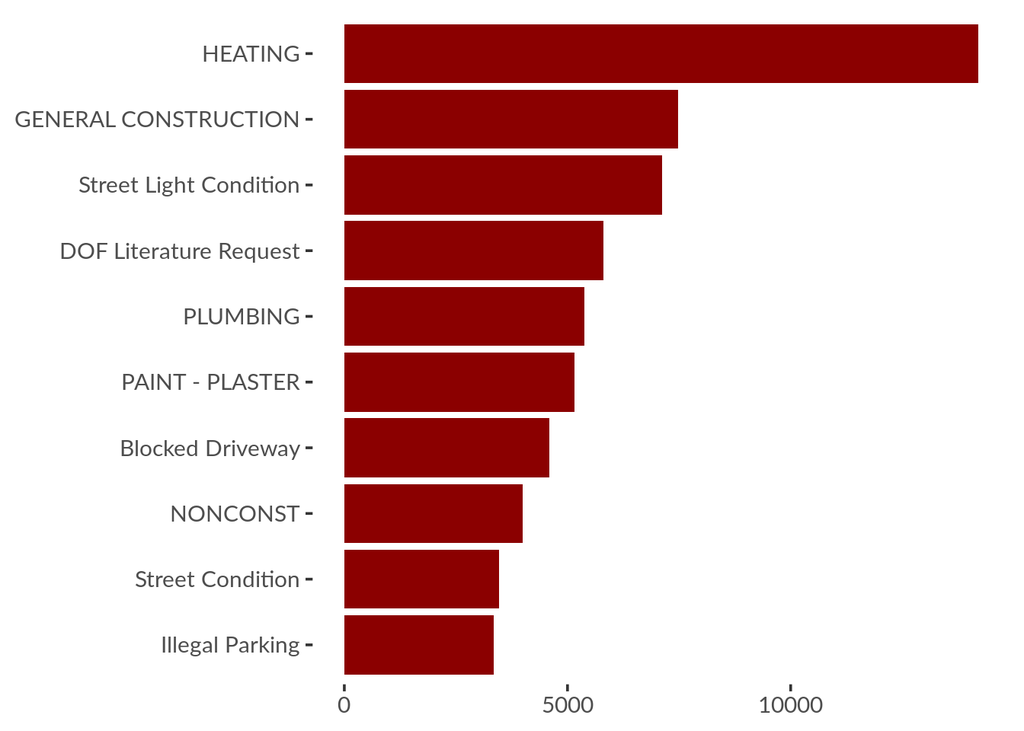

```r
ggplot(count_complaint2[1:10], aes(reorder(`Complaint Type`, n), n)) +
    geom_col(fill = "red4") +
    labs(x = NULL, y = NULL) +
    coord_flip()
```

## 2.5 How it works

The basics of working with `data.table` are quite simple:

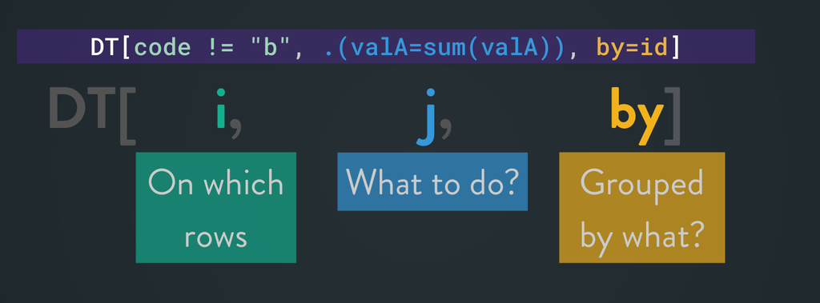

[*I took the image from the [slide](https://twitter.com/arun_sriniv/status/1150287843417346048) of Arun Srinivasan*]

which means: take data.table `dt`, subset rows using `i` and manipulate columns with `j`, grouped according to `by`. This syntax allows you to combine several operations in a very concise and consistent expression.

For example, the following line can be read as count the number of `Unique Key` per `Complaint Type`.

```r
complaints[, .(n = length(`Unique Key`)), by = .(`Complaint Type`)]
```

For further documentation on `data.table`, you could start with [intro vignette](https://rdatatable.gitlab.io/data.table/articles/datatable-intro.html), or learn from community-contributed [articles](https://github.com/Rdatatable/data.table/wiki/Articles).